# Introduzione Unsupervised Learning 🇮🇹

Introduzione ed esercizi

Francesco Pelosin

Dec 23, 2019 147 min read

Project

# Introduzione Unsupervised Learning

[figure not shown]

Tutorial by [**Francesco Pelosin**](https://francesco-p.github.io/)

## Qual è un buon clustering?

Innanzitutto dovremmo rispondere alla domanda: cos'è un cluster?...non è facile rispondere a questa domanda...

- Sicuramente un buon clustering rispetta due criteri fondamentali:
  - **Coesione interna:** Alta similarità tra gli oggetti della staessa classe.
  - **Dissimilarità esterna:** Bassa similarità tra oggetti di classi differenti.

## Approcci che vedremo

- Approccio di tipo **Partitioning**:
  - Construct various partitions and then evaluate them by some criterion, e.g., minimizing the sum of square errors.
  - Caso di studio: **K-Means**
- Approccio di tipo **Density-based**:
  - Based on connectivity and density functions.
  - Caso di studio: **DBSCAN**

# K-Means

## Algoritmo

Supponiamo di avere $\{\mathbf{x}_{1}, \dots, \mathbf{x}_{n}\}$ osservazioni di una variabile $\mathbf{x}$ nello spazio Euclideo $D$-dimensionale (nel nostro caso $D=2$).

**Goal**: Partizionare le osservazioni in un certo numero $K$ di clusters i quali hanno come centroidi il punto $\mathbf{\mu}_{k}$.

- $\mathbf{\mu}_{k}$ → Il centro del cluster (prototipo del cluster)
- $\mathbf{x}_{n}$ → Data point
- $r_{nk}$ → Variabili indicatrici, se il dato $\mathbf{x}_{n}$ appartiene al cluster $k$ allora $r_{nk} = 1$, altrimenti $0$.

$$J = \sum_{n=1}^{N}\sum_{k=1}^{K}r_{nk}\|\mathbf{x}_{n}-\mathbf{\mu}_{k} \|^{2}$$

Quello che ci resta da fare è $\min{J}$ (a volte viene chiamata distortion oppure inertia).

## Iterazioni in dettaglio

L'algoritmo K Means è un metodo iterativo di Expectation-Maximization (EM) ed è definito come segue:

1. Generiamo i $\mathbf{\mu}_{k}$ centroidi dei cluster randomicamente.
2. Assegnamo il punto $\mathbf{x}_{n}$ al cluster centroide ${k}$ più vicino settando $r_{kn}=1 $ se $k=\text{argmin}_{j} \parallel \mathbf{x}_{n} - \mathbf{\mu}_{j} \parallel$
3. Ricomputiamo i centroidi $\mathbf{\mu}_{k}$ in modo da minimizzare $J$. Ossia facciamo la media dei punti. $\mathbf{\mu}_{k} = \frac{\sum_{n} r_{nk} \mathbf{x}_{n}}{\sum{n}r_{nk}}$
4. Ripetere fino a convergenza

[figure not shown]

## Esempio

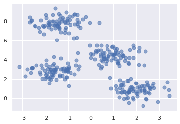

```python
# Sci-kit learn per la creazione di dati sintetici
from sklearn.datasets.samples_generator import make_blobs

# Librerie per visualizzazioni di dati
import matplotlib.pyplot as plt
import seaborn as sns
sns.set()

# Creiamo i dati sintetici
X, y_true = make_blobs(n_samples=300, centers=4, cluster_std=0.60, random_state=0)
plt.scatter(X[:, 0], X[:, 1], s=50, alpha=0.6)
```

```
[0 3 1 3 0 0 2 1 3 3 2 3 1 3 0 1 1 0 2 2 0 0 1 2 2 1 0 1 2 1 3 3 1 3 3 3 3
 3 2 0 1 2 1 1 2 2 3 2 3 0 2 0 3 0 0 2 3 2 3 0 3 1 3 2 2 2 3 0 3 2 1 2 3 2
 2 3 2 1 0 3 0 1 0 0 3 1 0 1 3 3 1 0 3 2 2 1 0 0 1 2 3 0 3 0 1 0 0 1 3 1 2
 2 0 3 0 1 3 0 0 1 2 0 2 0 0 0 0 2 0 2 3 2 2 0 3 2 2 3 1 3 3 2 1 2 1 2 3 1
 3 3 3 1 3 1 0 2 3 2 0 1 3 1 1 0 1 2 2 1 0 1 1 3 0 1 2 3 0 0 1 2 0 1 2 2 1
 1 1 1 0 3 1 2 1 1 2 2 2 1 2 3 1 2 0 2 1 3 2 3 1 3 1 2 1 1 3 2 2 0 0 1 3 0
 0 2 0 2 1 3 3 1 1 3 1 0 2 1 0 2 3 2 0 1 0 3 3 3 3 2 2 3 1 2 0 1 2 2 2 0 0
 3 1 1 2 0 3 2 1 3 1 0 0 2 2 1 0 0 0 1 3 3 0 0 1 0 0 0 3 2 3 1 0 0 3 3 3 0
 0 1 3 2]
```

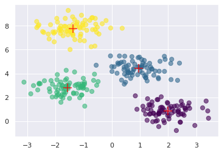

```python
from sklearn.cluster import KMeans

# Inizializziamo la classe KMeans e fittiamo i dati
kmeans = KMeans(n_clusters=4)
kmeans.fit(X)

# Printiamo le predizioni
y_kmeans = kmeans.predict(X)
print(y_kmeans)

# Visualizziamo le predizioni e coloriamo i punti di conseguenza
plt.scatter(X[:, 0], X[:, 1], c=y_kmeans, s=50, cmap='viridis', alpha=0.6)
centers = kmeans.cluster_centers_
plt.scatter(centers[:, 0], centers[:, 1], c='red', s=200, alpha=0.8, marker='+')
```

## Osservazioni

- Efficiente $O(ntk)$ ✔️
- Assunzione sul numero di clusters (dobbiamo sapere $k$ a priori) ❌❌
- Garanzia di convergenza, ma non al minimo globale (posso convergere ad una partizione poco significativa) 😕
- Non robusto con dati rumorosi (gli outliers influiscono molto nella partizione) ❌
- K Means funziona bene quando i cluster sono sferici e con la stessa densità ✔️

# DBSCAN: Density-Based Clustering Based on Connected Regions with High Density

## Algoritmo

L'algoritmo suddivide i punti in tre tipi:

- **Core Points** → Identificano punti in regioni "dense"
- **Density-reachable Points** → Identificano "boundary points" ai confini delle regioni dense
- **Noise Points** → Identificano punti che non appartengono a nessuna regione densa.

DBSCAN in a nutshell:

1. Inizio: tutti i punti sono settati a *unvisited*
2. Per ogni punto $p$ settato a *unvisited*
   - Setta $p$ come *visited*
   - if $|N_\epsilon(p)| < minPts$
     - Setta $p$ come *Noise*, goto step 2
     - *note that the noise label might be updated later*
   - Crea un nuovo cluster $C = \{p\}$
   - Crea una coda $Q=N_\epsilon(p)$
   - Per ogni $q$ in $Q$:
     - if $q$ is *unvisited*
       - Setta $q$ come *visited*
       - if $|N_\epsilon(q)|\geq minPts$:
         - $Q \gets Q \cup N_\epsilon(q)$
     - if $q$ non è ancora parte di nessun cluster, aggiungilo a $C$

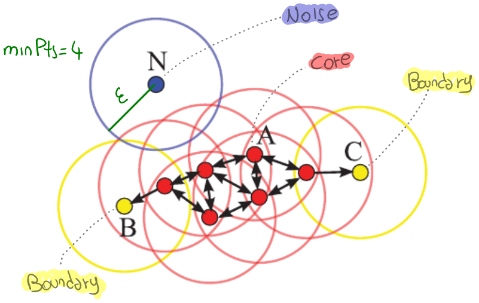

## Iterazioni in dettaglio

[figure not shown]

## Esempio

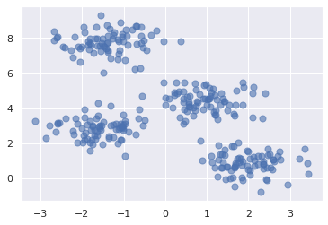

```python
# Sci-kit learn per la creazione di dati sintetici
from sklearn.datasets.samples_generator import make_blobs

# Creiamo i dati sintetici
X, y_true = make_blobs(n_samples=300, centers=4, cluster_std=0.60, random_state=0)
plt.scatter(X[:, 0], X[:, 1], s=50, alpha=0.6)
```

```
[ 2  0  1  0  2 -1  3  1  0  0  3  0  1  0  2  1  1  2  3  3  2  2  1  3
  3  1  2  1  3  1  0  0  1  0  0  0  0  0  3  2  1  3  1  1  3  3  0  3
  0  2  3  2  0  2  2  3  0  3  0  2  0  1  0  3  3  3  0  2  0  3  1  3
  0  3  3  0  3  1  2  0  2  1  2  2  0  1  2  1  0  0  1  2  0  3  3  1
  2  2  1  3  0  2  0  2  1  2  2  1  0  1  3  3  2  0  2  1  0  2  2  1
  3  2  3  2  2  2  2  3  2  3  0  3  3  2  0  3  3  0  1  0  0  3  1 -1
  1  3  0  1  0  0  0  1 -1  1  2  3  0  3  2  1  0  1  1  2  1  3 -1  1
  2  1  1  0  2  1  3  0  2  2  1  3  2  1  3  3  1  1  1  1  2  0  1  3
  1  1  3  3  3  1  3  0  1  3  2  3  1 -1  3  0  1  0  1  3  1  1  0  3
  3  2  2  1  0  2  2  3  2  3  1  0  0  1  1  0  1  2  3  1  2  3  0  3
  2  1  2  0  0  0  0  3  3 -1 -1  3  2  1  3  3  1  2  2  0  1  1  3  2
  0  3  1  0  1  2  2  3  3  1  2  2  2  1  0  0  2  2  1  2  2  2  0  3
  0  1 -1  2  0  0  0  2  2  1  0  3]
```

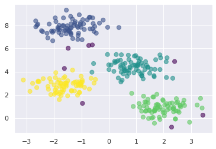

```python
from sklearn.cluster import DBSCAN

# Inizializziamo la classe KMeans e fittiamo i dati
dbscan = DBSCAN(eps=0.7, min_samples=10)
dbscan.fit(X)

# Printiamo le predizioni
print(dbscan.labels_)

# Visualizziamo le predizioni e coloriamo i punti di conseguenza
plt.scatter(X[:, 0], X[:, 1], c=dbscan.labels_, s=50, cmap='viridis', alpha=0.6)
```

## Osservazioni

- Genera cluster di forma arbitraria ✔️ ✔️
- Ottimo a gestire il Noise (outliers) ✔️ ✔️
- Efficiente $O(nlogn)$ ✔️
- Incapace di distinguere clusters con densità diverse ❌
- Parametri da settare PAINFUL! ❌❌

# Hands on Lab! 👨‍💻

## Challenge: KMeans vs DBSCAN

In questa challenge vi viene chiesto semplicemente di giocare con i parametri degli algoritmi e di capire come si comportano nei diversi scenari.

Quali sono i pro ed i contro d'utilizzo?

### Blob di dimensione diversa

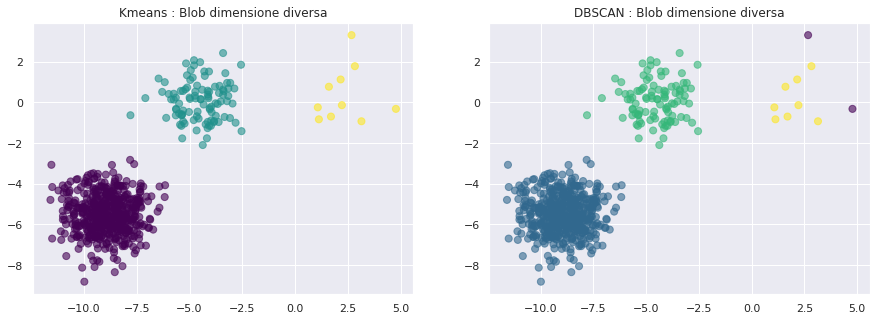

```
[ 0  0  0  0  0  0  0  0  0  0  0  0  0  0  0  0  0  0  0  0  0  0  0  0
  0  0  0  0  0  0  0  0  0  0  0  0  0  0  0  0  0  0  0  0  0  0  0  0
  0  0  0  0  0  0  0  0  0  0  0  0  0  0  0  0  0  0  0  0  0  0  0  0
  0  0  0  0  0  0  0  0  0  0  0  0  0  0  0  0  0  0  0  0  0  0  0  0
  0  0  0  0  0  0  0  0  0  0  0  0  0  0  0  0  0  0  0  0  0  0  0  0
  0  0  0  0  0  0  0  0  0  0  0  0  0  0  0  0  0  0  0  0  0  0  0  0
  0  0  0  0  0  0  0  0  0  0  0  0  0  0  0  0  0  0  0  0  0  0  0  0
  0  0  0  0  0  0  0  0  0  0  0  0  0  0  0  0  0  0  0  0  0  0  0  0
  0  0  0  0  0  0  0  0  0  0  0  0  0  0  0  0  0  0  0  0  0  0  0  0
  0  0  0  0  0  0  0  0  0  0  0  0  0  0  0  0  0  0  0  0  0  0  0  0
  0  0  0  0  0  0  0  0  0  0  0  0  0  0  0  0  0  0  0  0  0  0  0  0
  0  0  0  0  0  0  0  0  0  0  0  0  0  0  0  0  0  0  0  0  0  0  0  0
  0  0  0  0  0  0  0  0  0  0  0  0  0  0  0  0  0  0  0  0  0  0  0  0
  0  0  0  0  0  0  0  0  0  0  0  0  0  0  0  0  0  0  0  0  0  0  0  0
  0  0  0  0  0  0  0  0  0  0  0  0  0  0  0  0  0  0  0  0  0  0  0  0
  0  0  0  0  0  0  0  0  0  0  0  0  0  0  0  0  0  0  0  0  0  0  0  0
  0  0  0  0  0  0  0  0  0  0  0  0  0  0  0  0  0  0  0  0  0  0  0  0
  0  0  0  0  0  0  0  0  0  0  0  0  0  0  0  0  0  0  0  0  0  0  0  0
  0  0  0  0  0  0  0  0  0  0  0  0  0  0  0  0  0  0  0  0  0  0  0  0
  0  0  0  0  0  0  0  0  0  0  0  0  0  0  0  0  0  0  0  0  0  0  0  0
  0  0  0  0  0  0  0  0  0  0  0  0  0  0  0  0  0  0  0  0  1  1  1  1
  1  1  1  1  1  1  1  1  1  1  1  1  1  1  1  1  1  1  1  1  1  1  1  1
  1  1  1  1  1  1  1  1  1  1  1  1  1  1  1  1  1  1  1  1  1  1  1  1
  1  1  1  1  1  1  1  1  1  1  1  1  1  1  1  1  1  1  1  1  1  1  1  1
  1  1  1  1  1  1  1  1  1  1  1  1  1  1  1  1  1  1  1  1  1  1  1  1
  2 -1 -1  2  2  2  2  2  2  2]
```

```python
import numpy as np
import matplotlib.pyplot as plt
from sklearn.cluster import KMeans
from sklearn.datasets import make_blobs
from sklearn.cluster import DBSCAN

n_samples = 1500
random_state = 170
X, y = make_blobs(n_samples=n_samples, random_state=random_state)
X_filtered = np.vstack((X[y == 0][:500], X[y == 1][:100], X[y == 2][:10]))


# -----------------Modificare i parametri degli algoritmi-----------------------
# Kmeans
y_pred = KMeans(n_clusters=3, random_state=random_state).fit_predict(X_filtered)

# DBSCAN
y_pred2 = DBSCAN(eps=1.5, min_samples=3).fit_predict(X_filtered)

# ------------------------------------------------------------------------------


# Plot
fig, (ax1,ax2) = plt.subplots(1,2,figsize=(15,5))
ax1.scatter(X_filtered[:, 0], X_filtered[:, 1], c=y_pred, alpha=0.6, s=50, cmap='viridis')
ax1.set_title("Kmeans : Blob dimensione diversa")

ax2.scatter(X_filtered[:, 0], X_filtered[:, 1], c=y_pred2, alpha=0.6, s=50, cmap='viridis')
ax2.set_title("DBSCAN : Blob dimensione diversa")

plt.show()
print(y_pred2)
```

### Blob con varianza diversa

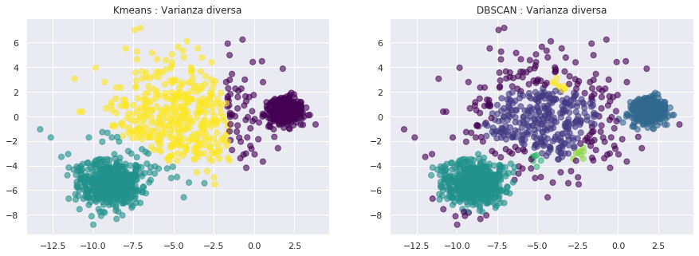

```python
n_samples = 1500
random_state = 170
X, y = make_blobs(n_samples=n_samples, random_state=random_state)
X_varied, y_varied = make_blobs(n_samples=n_samples,
                                cluster_std=[1.0, 2.5, 0.5],
                                random_state=random_state)

# -----------------Modificare i parametri degli algoritmi-----------------------
# Kmeans
y_pred = KMeans(n_clusters=3, random_state=random_state).fit_predict(X_varied)

# DBSCAN
y_pred2 = DBSCAN(eps=0.6, min_samples=10).fit_predict(X_varied)
# ------------------------------------------------------------------------------

# Plot data

fig, (ax1,ax2) = plt.subplots(1,2,figsize=(15,5))
ax1.scatter(X_varied[:, 0], X_varied[:, 1], c=y_pred, alpha=0.6, s=50, cmap='viridis')
ax1.set_title("Kmeans : Varianza diversa")

ax2.scatter(X_varied[:, 0], X_varied[:, 1], c=y_pred2, alpha=0.6, s=50, cmap='viridis')
ax2.set_title("DBSCAN : Varianza diversa")

plt.show()
```

### Blob con distribuzione [anisotropica](https://it.wikipedia.org/wiki/Anisotropia)

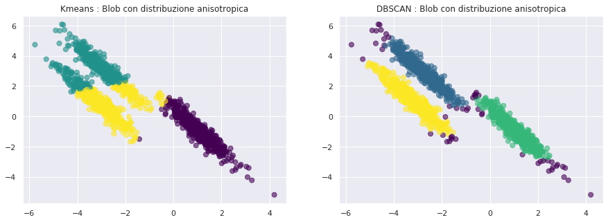

```python
n_samples = 1500
random_state = 170
X, y = make_blobs(n_samples=n_samples, random_state=random_state)
transformation = [[0.60834549, -0.63667341], [-0.40887718, 0.85253229]]
X_aniso = np.dot(X, transformation)

# -----------------Modificare i parametri degli algoritmi-----------------------
# Kmeans
y_pred = KMeans(n_clusters=3, random_state=random_state).fit_predict(X_aniso)

# DBSCAN
y_pred2 = DBSCAN(eps=0.3, min_samples=10).fit_predict(X_aniso)
# ------------------------------------------------------------------------------


# Plot data
fig, (ax1,ax2) = plt.subplots(1,2,figsize=(15,5))
ax1.scatter(X_aniso[:, 0], X_aniso[:, 1], c=y_pred, alpha=0.6, s=50, cmap='viridis')
ax1.set_title("Kmeans : Blob con distribuzione anisotropica")


ax2.scatter(X_aniso[:, 0], X_aniso[:, 1], c=y_pred2, alpha=0.6, s=50, cmap='viridis')
ax2.set_title("DBSCAN : Blob con distribuzione anisotropica")

plt.show()
```

## Challenge: Digits Dataset

1. Applicare KMeans al dataset Digits e visualizzare i centroidi trovati
2. Plot dei primi 10 esempi e dei relativi centroidi ai quali sono stati assegnati
3. Visualizzare come cambiano le imamgini relative ai centroidi per ogni iterazione dell'algoritmo (10 iterazioni) e plottare la relativa distorsione. Per la riproducibilità dell' esercizio inizializzare l'algoritmo con i seguenti parametri: `KMeans(n_clusters=10, max_iter=???, n_init=1, init='random', random_state=1337)`

Hints:

- Le immagini sono 8x8 (usare `.reshape()` per visualizzarle)
- Il numero di classi 10

```python
from sklearn.datasets import load_digits

# Load del dataset
digits = load_digits()
digits.data.shape
```

```
(1797, 64)
```

[figure not shown]

```python
# Visualizzazione del primo elemento
ax = plt.axes(xticks=[], yticks=[])
ax.imshow(digits.data[0,:].reshape(8,8), cmap="Greys")
```

```python
# Run kmeans!
kmeans = KMeans(n_clusters=10)
kmeans.fit(digits.data)
```

```
KMeans(algorithm='auto', copy_x=True, init='k-means++', max_iter=300,
       n_clusters=10, n_init=10, n_jobs=None, precompute_distances='auto',
       random_state=None, tol=0.0001, verbose=0)
```

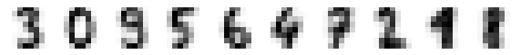

```python
# Visualizziamo i centroidi trovati
fig, axs = plt.subplots(1,10, figsize=(10,10))

for i in range(10):
  axs[i].imshow(kmeans.cluster_centers_[i].reshape((8,8)), cmap="Greys")
  axs[i].set_xticks([])
  axs[i].set_yticks([])
```

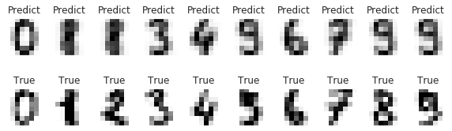

```python
fig, axs = plt.subplots(2,10, figsize=(10,3))

# Plot dei primi 10 esempi e dei relativi centroidi ai quali sono stati assegnati
for i in range(10):
  axs[0,i].imshow(kmeans.cluster_centers_[kmeans.labels_[i]].reshape((8,8)), cmap="Greys")
  axs[1,i].imshow(digits.data[i,:].reshape((8,8)), cmap="Greys")
  axs[0,i].set_title("Predict")
  axs[1,i].set_title("True")

  axs[0,i].set_xticks([])
  axs[1,i].set_xticks([])
  axs[0,i].set_yticks([])
  axs[1,i].set_yticks([])
```

```
Iterazione: 1 | Distorsion = 1337585.3597432133
```

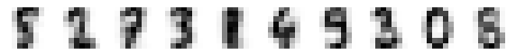

```
Iterazione: 2 | Distorsion = 1259151.9332380705
```

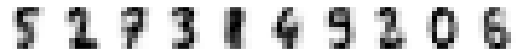

```
Iterazione: 3 | Distorsion = 1221712.9878818558
```

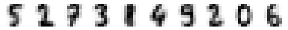

```
Iterazione: 4 | Distorsion = 1203850.9250365878
```

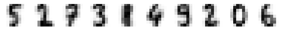

```
Iterazione: 5 | Distorsion = 1199313.5990915794
```

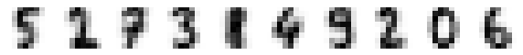

```
Iterazione: 6 | Distorsion = 1197505.6906791048
```

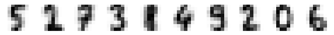

```
Iterazione: 7 | Distorsion = 1197036.6868473147
```

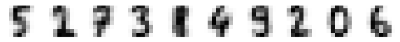

```
Iterazione: 8 | Distorsion = 1196955.1735587267
```

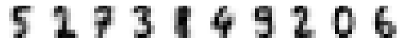

```
Iterazione: 9 | Distorsion = 1196902.072017943
```

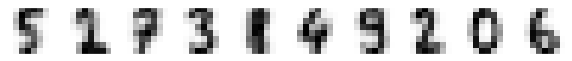

```
Iterazione: 10 | Distorsion = 1196881.9347686144
```

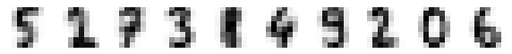

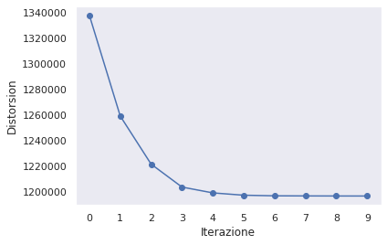

```python
distortion = []
for i in range(10):
    max_iter = i+1

    # Facciamo andare kmeans con (i+1) iterazioni
    k_means = KMeans(n_clusters=10, max_iter=max_iter, n_init=1, init='random', random_state=1337)
    k_means.fit(digits.data)

    # Print della distorsione (intertial_ su scikit)
    print (f"Iterazione: {max_iter} | Distorsion = {k_means.inertia_}")
    distortion.append(k_means.inertia_)

    # Visualizzazione dei centroidi ad ogni iterazione
    fig, axs = plt.subplots(1,10, figsize=(10,2))
    for j, ax in enumerate(axs.flatten()):
      ax.imshow(k_means.cluster_centers_[j].reshape((8,8)), cmap="Greys")
      ax.set_xticks([])
      ax.set_yticks([])
    plt.show()

# Plot della distorsione
plt.plot(distortion, 'o', linestyle='-')
plt.xticks([x for x in range(10)])
plt.ylabel("Distorsion")
plt.xlabel("Iterazione")
plt.grid()
```

## Valutazione del clustering

Come facciamo a sapere se il nostro algoritmo ha dato dei buoni risultati o meno? Servono delle metriche che studino la bontà di un clustering.

...ma...

Qual è il problema principale della valutazione in ambito unsupervised?

[figure not shown]

**NON ABBIAMO IL GROUND TRUTH!**

Nel caso in cui non abbiamo nessun tipo di etichetta si utilizzano **valutazioni intriseche** come ad esempio il Silhouette coefficient.

Nel caso, però, in cui abbiamo le etichette disponibili possiamo fare delle **valutazioni estrinseche**: ARI, AUROC, F-Score [ecc.](https://scikit-learn.org/stable/modules/model_evaluation.html#classification-metrics) Nel caso del Digit Dataset abbiamo le etichette disponibili possiamo dunque plottarci l'accuracy e la confusion matrix.

```
Accuracy : 0.7935447968836951
```

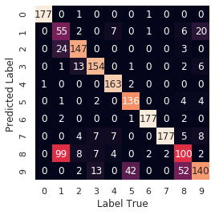

```python
from scipy.stats import mode
import numpy as np
from sklearn.metrics import confusion_matrix
from sklearn.metrics import accuracy_score


# Run kmeans!
k_means = KMeans(n_clusters=10)
k_means.fit(digits.data)

# Perchè questo passaggio??? :)
labels = np.zeros_like(k_means.labels_)
for i in range(10):
    mask = (k_means.labels_ == i)
    labels[mask] = mode(digits.target[mask])[0]

accuracy = accuracy_score(digits.target, labels)
print(f"Accuracy : {accuracy}")

# Confusion Matrix
mat = confusion_matrix(digits.target, labels)
sns.heatmap(mat.T, square=True, annot=True, fmt='d', cbar=False,
            xticklabels=digits.target_names,
            yticklabels=digits.target_names)
plt.xlabel('Label True')
plt.ylabel('Predicted Label ')

plt.show()
```

```python
# Possiamo clcolare l'accuracy anche così

mat.trace()/mat.sum()
```

```
0.7935447968836951
```

## Challenge: Quantizzazione Immagine

Un'immagine è formata da pixels. Ogni pixel è identifica un colore. Ogni colore è identificato da una tripletta RGB che corrispondono ai canali Red Green Blue. Normalmente i canali RGB sono su 8bit ciascuno e di conseguenza codificano $2^{8}$ intensità ciascuno.

- Quante combinazioni di colori possiamo avere in totale?

```
    r       g      b
[0..255][0..255][0..255]
```

Riusciamo a quantizzare un'immagine comprimendola solo su 16 colori?

- Usare KMeans per comprimere l'immagine su 16 colori.

```
(427, 640, 3)
```

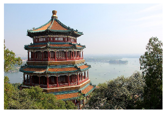

```python
from sklearn.datasets import load_sample_image

# Show dell'immagine
china = load_sample_image("china.jpg")
ax = plt.axes(xticks=[], yticks=[])
ax.imshow(china)
china.shape
```

```python
# Scaliamo i dati da 0..1
data = china / 255.0
data = data.reshape(427 * 640, 3)
data.shape
```

```
(273280, 3)
```

```python
from sklearn.cluster import KMeans

# Embeddiamo i colori su 16 dimensioni
kmeans = KMeans(n_clusters=16)
kmeans.fit(data)
```

```
KMeans(algorithm='auto', copy_x=True, init='k-means++', max_iter=300,
       n_clusters=16, n_init=10, n_jobs=None, precompute_distances='auto',
       random_state=None, tol=0.0001, verbose=0)
```

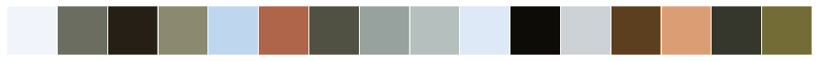

```python
# Visualizzazione dei centroidi
cmap = sns.palplot(kmeans.cluster_centers_)
```

[figure not shown]

```python
# Show immagine quantizzata
ax = plt.axes(xticks=[], yticks=[])
ax.imshow(kmeans.cluster_centers_[kmeans.predict(data)].reshape(china.shape))
```

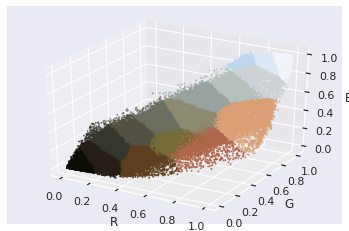

```python
from mpl_toolkits.mplot3d import Axes3D
from matplotlib.colors import ListedColormap

# Creazione della colormap utile
cmap = ListedColormap(kmeans.cluster_centers_)

# Show clusters nello spazio (normalizzato) RGB
sp = plt.figure().add_subplot(111, projection='3d')
sp.set_xlabel('R')
sp.set_ylabel('G')
sp.set_zlabel('B')
sp.scatter(data[:,0], data[:,1], data[:,2], s=1, c=kmeans.labels_, cmap=cmap)
```

# Bonus

Woaah!! Se sei arrivato fino a qua significa che sei fortissimo!!!

Che ne dici di provare [HDBSCAN](https://hdbscan.readthedocs.io/en/latest/how_hdbscan_works.html)? HDBSCAN è l'evoluzione gerarchica di DBSCAN.

HDBSCAN non richiede il parametro $\varepsilon$ ma solamente $minPts$.

```python
# Installiamo il modulo direttamente dalla cella con il comando magico !pip install
!pip install hdbscan

import hdbscan

# Tocca a te! Enjoy!
```

# Risorse

- *Christopher M.Bishop*: Pattern Recognition and Machine Learning
- *Tan, Steinbach, Kumar, Pang. Pearson.*: Introduction to Data Mining
- Cos'è un cluster? Principio [Gestalt](https://en.wikipedia.org/wiki/Gestalt_psychology)

ml tutorial

[figure not shown]

##### [Francesco Pelosin](https://francesco-p.github.io/)

###### Ph.D. Student in Computer Science

My main interests are Computer Visioni/Pattern Recognition with particular focus on Unsupervised approaches